# CAS Webinar - Special Topics in GLM

January 19, 2023

# Special Topics in GLM

## 1 Introduction

We want to demonstrate several GLM techniques by building a claim frequency model using the French motor third-party liability dataset.

## 2 Descrption of the Dataset

In the freMTPL2freq dataset, risk features are collected for motor third-part liability policies (observed mostly on one year). In addition, we have claim numbers by policy(CASdatasets).The data dictionary is as follows.

- IDpol The policy ID (used to link with the claims dataset).
- ClaimNb Number of claims during the exposure period.
- Exposure The period of exposure for a policy, in years.
- VehPower The power of the car (ordered values).
- VehAge The vehicle age, in years.
- DrivAge The driver age, in years (in France, people can drive a car at 18).
- BonusMalus Bonus/malus, between 50 and 350: <100 means bonus, >100 means malus in France.
- VehBrand The car brand (unknown categories).
- VehGas The car gas, Diesel or regular.
- Area The density value of the city community where the car driver lives in: from “A” for rural area to “F” for urban centre.
- Density The density of inhabitants (number of inhabitants per square-kilometer) of the city where the car driver lives in.
- Region The policy region in France (based on the 1970-2015 classification).

## 2.1 Importing of the Library

```r
rm(list=ls())
library(kableExtra)
library(grplasso)
library(car)
```

```r
library(corrplot)
library(glmnet)
library(car)
library(corrplot)
library(splines)
library(dplyr)
```

## 2.2 Importing of the Dataset

```r
data = read.csv("freMTPL2freq.csv", header=TRUE)
data_1 = data %>% select(-IDpol)
head(data_1)
```

## 2.3 Correlation Between Numeric Variables

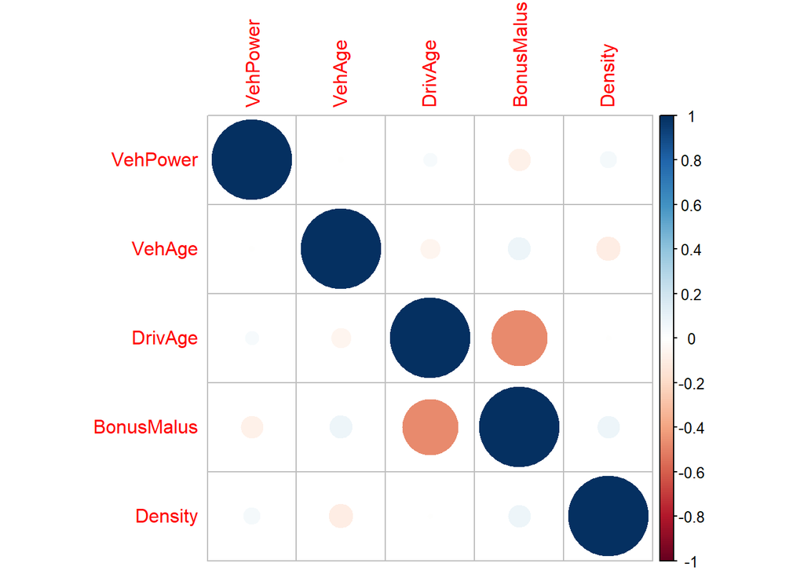

```r
corrplot(cor(data_1 %>% select(-Exposure, -ClaimNb,-Area, -VehBrand, -VehGas, -Region)))
```

## 2.4 Splitting Train and Test Datasets

70% of the data is used for model training while the rest 30% is used for testing.

```r
train_size = floor(0.7 * nrow(data_1))
set.seed(1)
train_idx = sample(seq_len(nrow(data_1)), size = train_size)
train = data_1[train_idx, ]
test = data_1[-train_idx, ]
```

## 3 Topic 1 The Theory Framework

The formula for multiple regression is defined as $y_i = \beta_0 + \beta_1 x_{i1} +\beta_2 x_{i2}+...+\beta_p x_{ip}+ \varepsilon$ where i = 1, …, n(Number of rows). The objective function of multiple regression is the error term, $\sum_{i=1}^{n}(y_i - \beta_0 + \beta_1 x_{i1} +\beta_2 x_{i2}+...+\beta_p x_{ip})^2$ Based on this analysis framework, a series of statistical tests such as $R^2$ and F test are developed.

The formula for GLM is $\ln(y_i) = \beta_0 + \beta_1 x_{i1} +\beta_2 x_{i2}+...+\beta_p x_{ip}$ Its objective function is to maximize $\ln(\prod_{i=1}^{n}P(\mu_i = y_i))$ where we want to maximize the product of the likihood function. As such, the $R^2$ and F test are not inherent statistical tests in the GLM framework.

## 4 Topic 2 Nonlinearity

For demonstration purpose, in this section we will use single variable, DrivAge in prediction. ## 4.1 Linear Fitting(underfit)

```r
set.seed(1)
model = glm(ClaimNb ~ DrivAge, data=train, family= "poisson"(link='log'),weights=Exposure)
model
```

## 4.1.1 Goodness of Fit(Deviance residuals test)

```r
cat("Deviance residuals test p-value: ",
1-pchisq(model$deviance, model$df.residual), end="\n")
```

[output not shown]

## 4.1.2 Linear Fitting(Visualization)

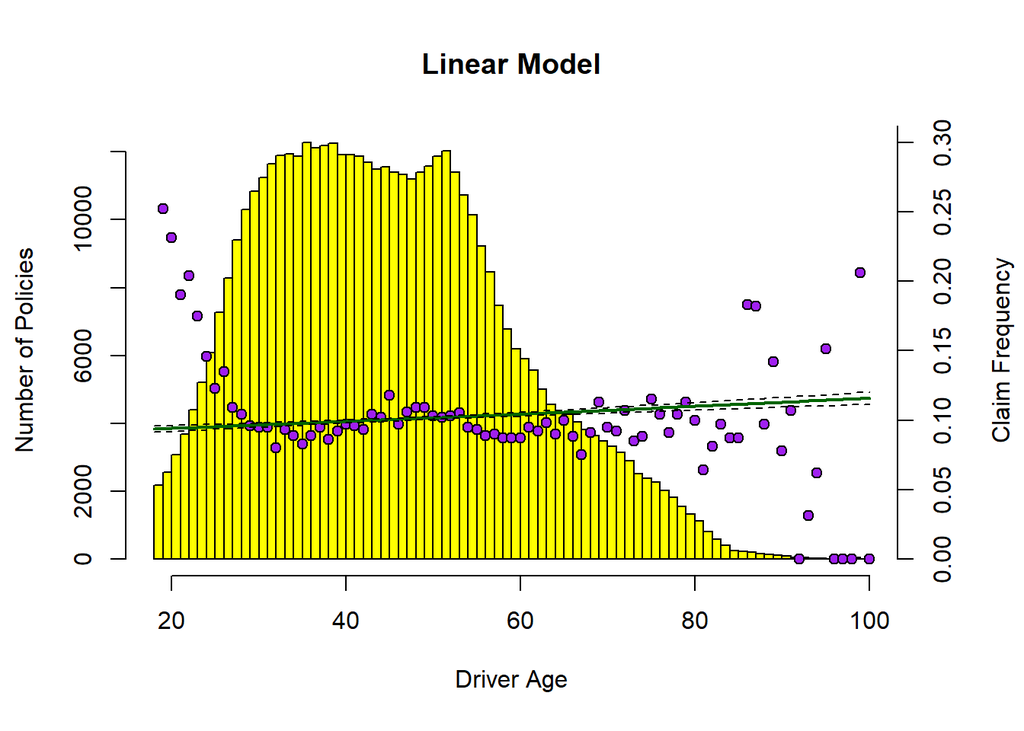

```r
chart = function(main){
  DrivAge_range = range(train$DrivAge)
DrivAge_grid = seq(from = DrivAge_range[1], to = DrivAge_range[2])
pred = predict(model, type = "response", newdata = list(DrivAge = DrivAge_grid ), se = TRUE)
table = train%>%group_by(DrivAge)%>%summarise(ex=sum(Exposure),cc=sum(ClaimNb))%>%mutate(fr=round((cc / ex), 3))
#balance factor
balance_fac = sum(table$fr)/sum(pred$fit)
par(mar = c(5, 4, 4, 4) + 0.3)
h = (hist(train$DrivAge,breaks = nrow(table),col = "yellow",main = main, xlab = "Driver Age", ylab="Number of Policies"))
par(new=TRUE)
plot(table$DrivAge,table$fr,bg ="purple",pch=21, axes = FALSE, xaxt="n",yaxt="n",xlab="",ylab="", ylim=c(0,0.3))
axis(side = 4, at = pretty(range(table$fr)))
mtext("Claim Frequency", side = 4, line = 3)
lines(DrivAge_grid, pred$fit*balance_fac, col = "darkgreen", lwd = 2)
lines(DrivAge_grid, pred$fit*balance_fac + 2*pred$se, lty = "dashed")
lines(DrivAge_grid, pred$fit*balance_fac - 2*pred$se, lty = "dashed")

}

chart("Linear Model")
```

## 4.2 Polynomial Fitting(wagging tail)

```r
set.seed(1)
model = glm(ClaimNb ~ poly(DrivAge,degree = 3), data=train, family= "poisson"(link='log'),weights=Exposure)
```

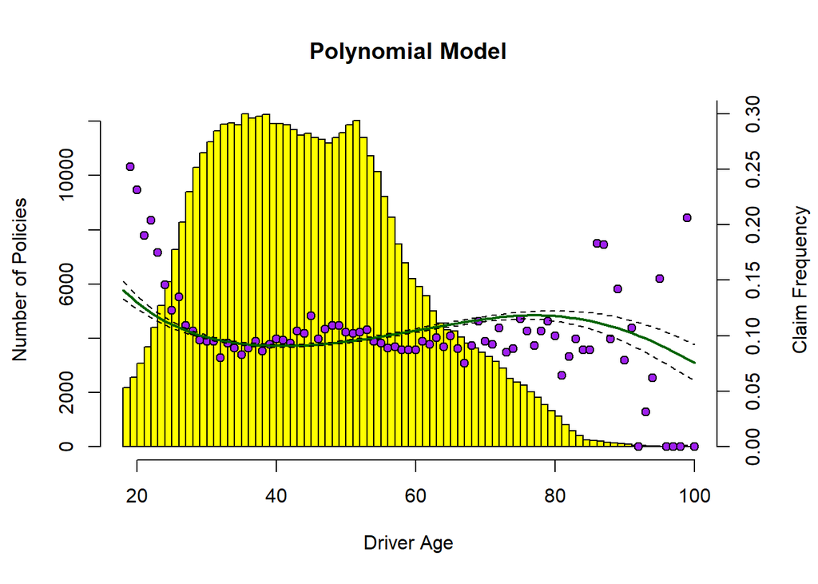

```r
chart("Polynomial Model")
```

## 4.3 Piecewise Polynomial(unstable predictions)

```r
k_1 = 25
k_2 = 35
k_3 = 45
set.seed(1)
model = glm(ClaimNb ~ DrivAge + DrivAge^2 + I((DrivAge-k_1)^3*(DrivAge>=k_1))+ I((DrivAge-k_2)^3*(DrivAge>=k_2))+ I((DrivAge-k_3)^3*(DrivAge>=k_3)), data=train, family= "poisson"(link='log'),weights=Exposure)
```

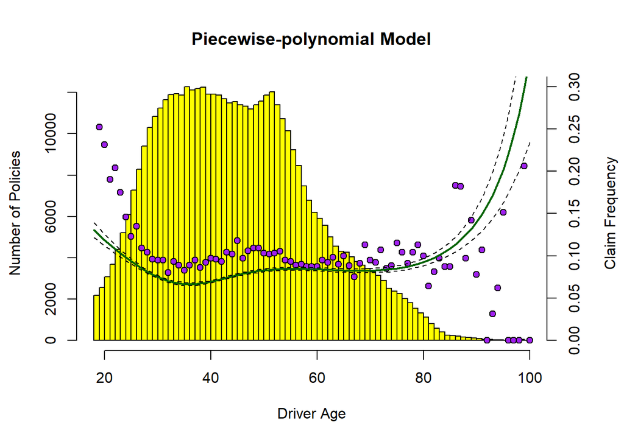

```r
chart("Piecewise-polynomial Model")
```

## 4.4 Natural Spline

## 4.4.1 Natural Spline Concept

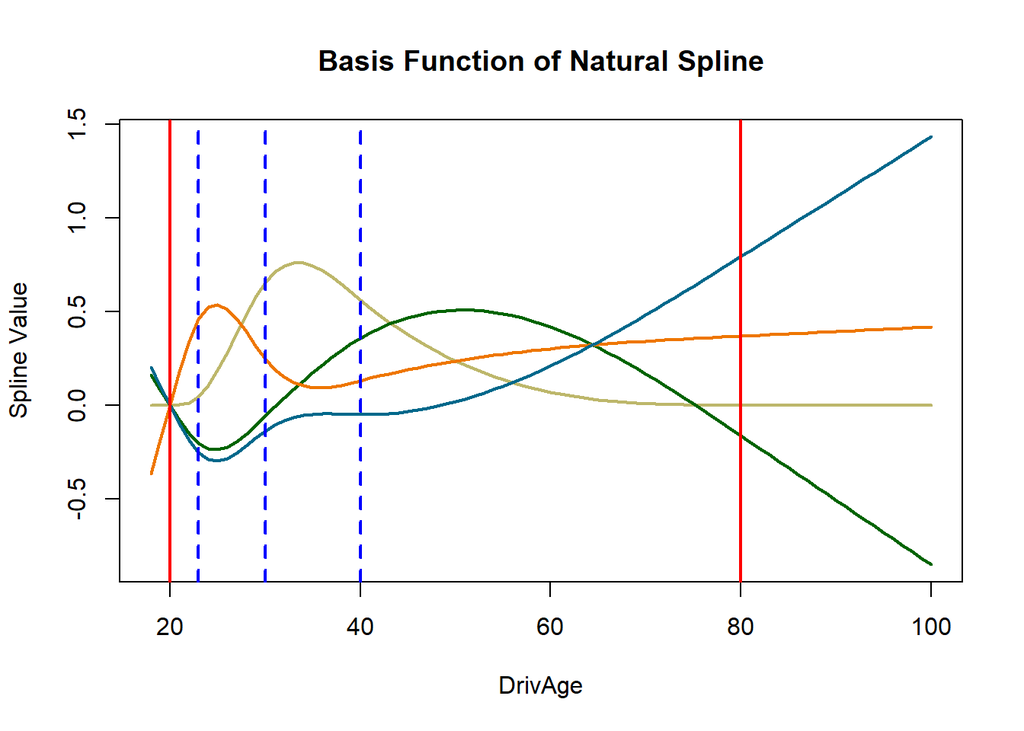

```r
bk_1 = 20
bk_2 = 80
k_1 = 23
k_2 = 30
k_3 = 40

DrivAge =seq(range(train$DrivAge)[1],range(train$DrivAge)[2])
ns = ns(DrivAge, Boundary.knots = c(bk_1,bk_2), knots = c(k_1,k_2,k_3))
colors = c("darkkhaki", "darkgreen", "darkorange2", "deepskyblue4")
plot(range(DrivAge), range(ns), type="n", main="Basis Function of Natural Spline",
     xlab="DrivAge", ylab="Spline Value")
for (j in 1:ncol(ns)) {
  lines(DrivAge, ns[,j], col=colors[j], lwd=2)
}
abline(v = c(bk_1,bk_2),col = "red",lwd = 2)
abline(v = c(k_1,k_2,k_3), col = "blue",lty = "dashed",lwd = 2)
```

## 4.4.2 GLM using Natural Spline

```r
set.seed(1)
model = glm(ClaimNb ~ ns(DrivAge,Boundary.knots = c(bk_1,bk_2), knots = c(k_1,k_2,k_3)), data=train, family= "poisson"(link='log'),weights=Exposure)
```

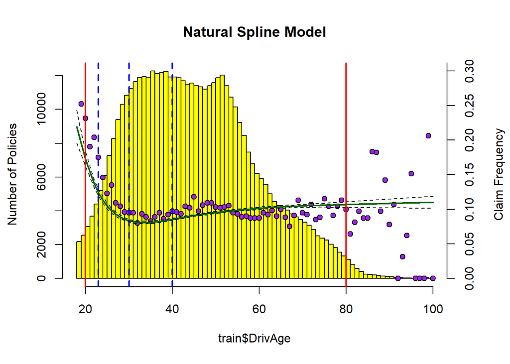

```r
DrivAge_range = range(train$DrivAge)
DrivAge_grid = seq(from = DrivAge_range[1], to = DrivAge_range[2])
pred = predict(model, type = "response", newdata = list(DrivAge = DrivAge_grid ), se = TRUE)
table = train%>%group_by(DrivAge)%>%summarise(ex=sum(Exposure),cc=sum(ClaimNb))%>%mutate(fr=round((cc / ex), 3))
#balance factor
balance_fac = sum(table$fr)/sum(pred$fit)
par(mar = c(5, 4, 4, 4) + 0.3)
h = (hist(train$DrivAge,breaks = nrow(table),col = "yellow",main = "Natural Spline Model", ylab="Number of Policies"))
par(new=TRUE)
plot(table$DrivAge,table$fr,bg ="purple",pch=21, axes = FALSE, xaxt="n",yaxt="n",xlab="",ylab="", ylim=c(0,0.3))
axis(side = 4, at = pretty(range(table$fr)))
mtext("Claim Frequency", side = 4, line = 3)
lines(DrivAge_grid, pred$fit*balance_fac, col = "darkgreen", lwd = 2)
lines(DrivAge_grid, pred$fit*balance_fac + 2*pred$se, lty = "dashed")
lines(DrivAge_grid, pred$fit*balance_fac - 2*pred$se, lty = "dashed")
abline(v = c(bk_1,bk_2),col = "red",lwd = 2)
abline(v = c(k_1,k_2,k_3), col = "blue",lty = "dashed",lwd = 2)
```

## 5 Topic 3 Regularization and Variable Selection

## 5.1 Lasso Model

## 5.1.1 Lasso Concept

The objective function of Lasso is to maximize $\ln(\prod_{i=1}^{n}P(\mu_i = y_i))-\lambda\sum_{i=1}^{p}|\beta_j|$, where we want to maximize this function to calculate $\beta$

## 5.1.2 Tuning Parameter Determination

```r
splined = ns(train$DrivAge,Boundary.knots = c(bk_1,bk_2), knots = c(k_1,k_2,k_3))
splined_df = as.data.frame(splined)
X = cbind(train,splined_df)
X = X%>% select(-ClaimNb,-Exposure,-DrivAge)
X = model.matrix(~.-1,data = X )
set.seed(1)
cv.lasso =cv.glmnet(x = X,
                    y = train$ClaimNb,
                    weights = train$Exposure,
                    family = "poisson",
                    alpha = 1,
                    nfolds=20)
```

```r
cv.lasso$lambda.min
```

## 5.1.3 GLM using Lasso Model

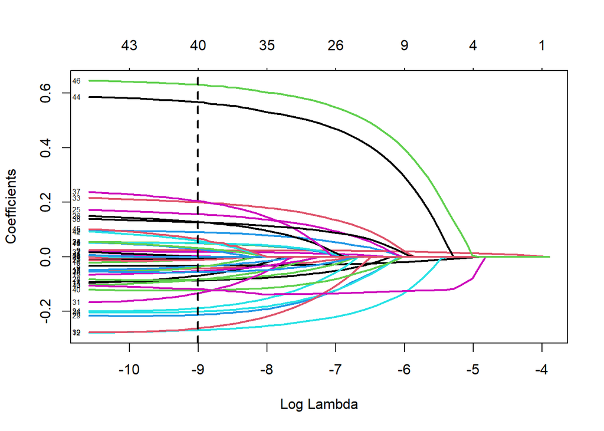

```r
mod_lasso = glmnet(x = X, y = train$ClaimNb,weights = train$Exposure, family= "poisson", alpha=1)
plot(mod_lasso,xvar="lambda",label=TRUE,lwd=2, main = "")
abline(v=log(cv.lasso$lambda.min),col='black',lty = 2,lwd=2)
```

## 5.1.4 Coefficients

```r
coef.lasso = coef(mod_lasso,s=cv.lasso$lambda.min)
coef.lasso
```

## 5.2 Ridge Model

## 5.2.1 Ridge Concept

The objective function of Ridge is to maximize $\ln(\prod_{i=1}^{n}P(\mu_i = y_i))-\lambda\sum_{i=1}^{p}\beta_j^2$, where we want to maximize this function to calculate $\beta$ ## 5.2.2 GLM using Ridge

```r
ridge = set.seed(1)
cv.ridge =cv.glmnet(x = X,
                    y = train$ClaimNb,
                    weights = train$Exposure,
                    family = "poisson",
                    alpha = 0,
                    nfolds=20)

mod_ridge = glmnet(x = X,
                    y = train$ClaimNb,
                    weights = train$Exposure,
                    family = "poisson",
                    alpha = 0)
coef.ridge = coef(mod_ridge,s=cv.ridge$lambda.min)
coef.ridge
```

## 5.3.2 GLM using adaptive Lasso

```r
gamma = 2
penalty.factor = 1/abs(coef.ridge[-1])^gamma
cv.adaptive_lasso = cv.glmnet(x = X,
                    y = train$ClaimNb,
                    weights = train$Exposure,
                    family = "poisson",
                    #lasso
                    alpha = 1,
                    nfolds=20,
                    penalty.factor = penalty.factor)
lambda = cv.adaptive_lasso$lambda.min
adaptive_lasso = glmnet(x = X,
                    y = train$ClaimNb,
                    weights = train$Exposure,
                    family = "poisson",
                    #lasso
                    alpha = 1,
                    penalty.factor = penalty.factor)
```

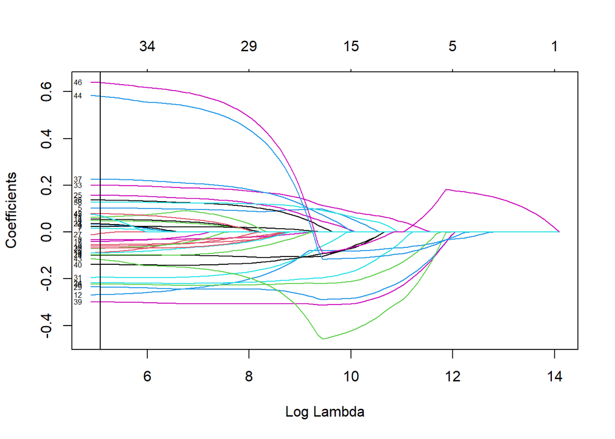

```r
plot(adaptive_lasso, xvar = "lambda", label = TRUE)
abline(v=log(lambda))
```

```r
coef.adaptive_lasso = coef(adaptive_lasso,s=lambda)
coef.adaptive_lasso
```

## 5.4 Group LASSO

```r
lambda = lambdamax(ClaimNb ~ .-Exposure - DrivAge +ns(DrivAge,Boundary.knots = c(bk_1,bk_2), knots = c(k_1,k_2,k_3)), data = train, penscale = sqrt, model = PoissReg())* 0.5^(0:5)
lambda = tail(lambda,1)
group_lasso <- grplasso(ClaimNb ~ .-Exposure - DrivAge +ns(DrivAge,Boundary.knots = c(bk_1,bk_2), knots = c(k_1,k_2,k_3)), data = train, model = PoissReg(), lambda = lambda)

coef.group_lasso = coef(group_lasso)
coef.group_lasso
```

## 5.5 Coefficient Comparison

```r
options(scipen=999)
coef_compare = cbind.data.frame(matrix(coef.ridge), matrix(coef.lasso), matrix(coef.adaptive_lasso))
rownames(coef_compare) = rownames(coef.ridge)
View(coef_compare)
```

Prediction

```r
splined = ns(test$DrivAge,Boundary.knots = c(bk_1,bk_2), knots = c(k_1,k_2,k_3))
splined_df = as.data.frame(splined)
test = test[,1:11]
newX = cbind(test,splined_df)
newX = newX%>% select(-ClaimNb,-Exposure,-DrivAge)
newX = model.matrix(~.-1,data = newX)
test$adaptive_lasso = predict(adaptive_lasso, newx = newX, s = lambda, type="response")
MSE = mean((test$adaptive_lasso-test$ClaimNb)^2)
cat("MSE of the adaptive lasso model is",MSE)
```

[output not shown]

Gini Index

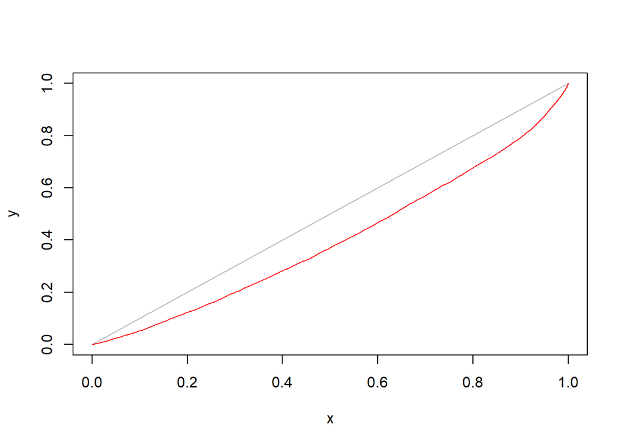

```r
o <- with(test, order(adaptive_lasso))
x <- with(test, cumsum(Exposure[o])/sum(Exposure))
y <- with(test, cumsum(ClaimNb[o])/sum(ClaimNb))

dx <- x[-1] - x[-length(x)]
h <- (y[-1] + y[-length(y)])/2
gini <- 2 * (0.5 - sum(h * dx))

plot(x = x, y = y, type = "n")
lines(x = c(0,1), y = c(0,1), col = "grey")
lines(x = x, y = y, col = "red")
```

## 6 Topic 4 Outlier Detection

## 6.1 Model Retrained

```r
set.seed(1)
adaptive_lasso_retrained = glm(ClaimNb ~.-VehGas -Density -DrivAge +ns(DrivAge, Boundary.knots = c(bk_1,bk_2), knots = c(k_1,k_2,k_3)), data=train, family= "poisson"(link='log'),weights=Exposure)
```

## 6.2 Outlier Detection Report

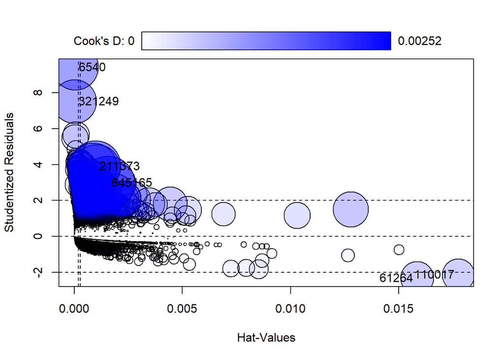

```r
influencePlot(adaptive_lasso_retrained)
```

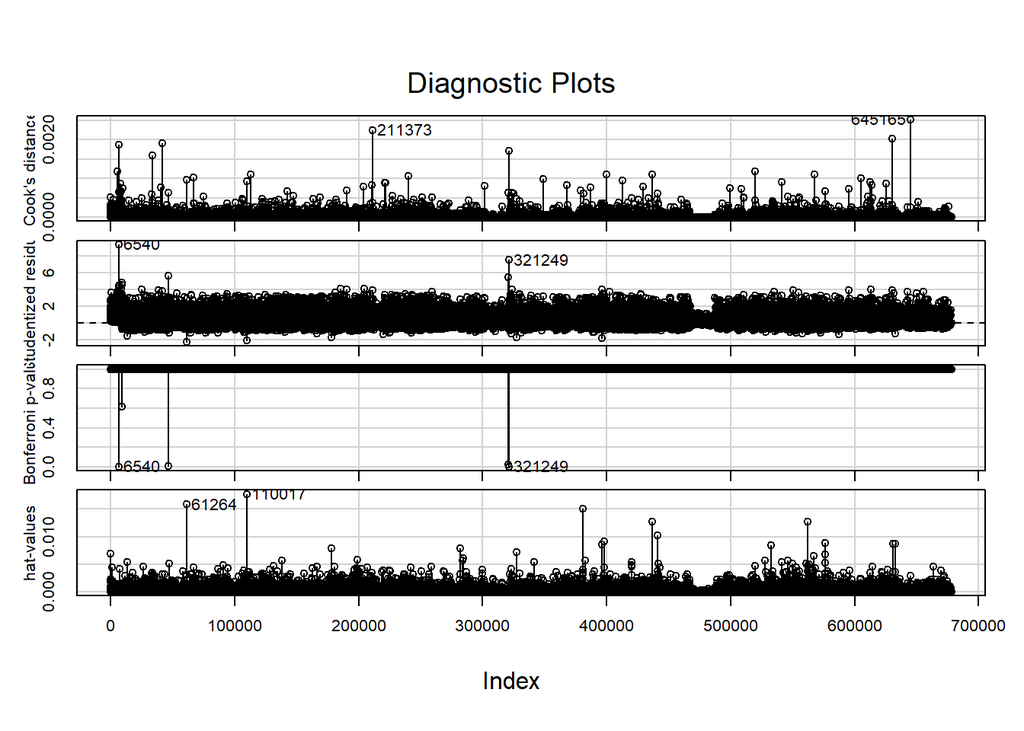

```r
influenceIndexPlot(adaptive_lasso_retrained)
```

## 6.3 Cook’s Distance

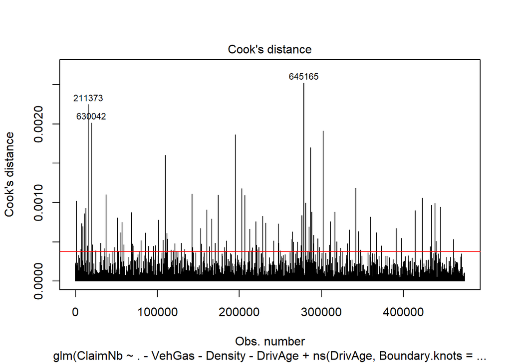

```r
p = length(adaptive_lasso_retrained$coefficients)
n = nrow(train)
plot(adaptive_lasso_retrained, which = 4, id.n = 3)
abline(h = p/n *4, col="red")
```

## 6.4 Cook’s Distance vs. Residuals

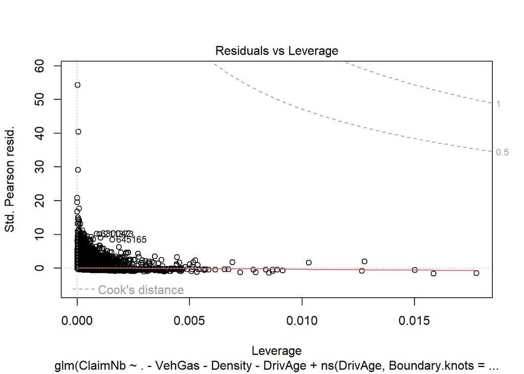

```r
plot(adaptive_lasso_retrained, which = 5)
```

## 6.5 DFBETAS plot

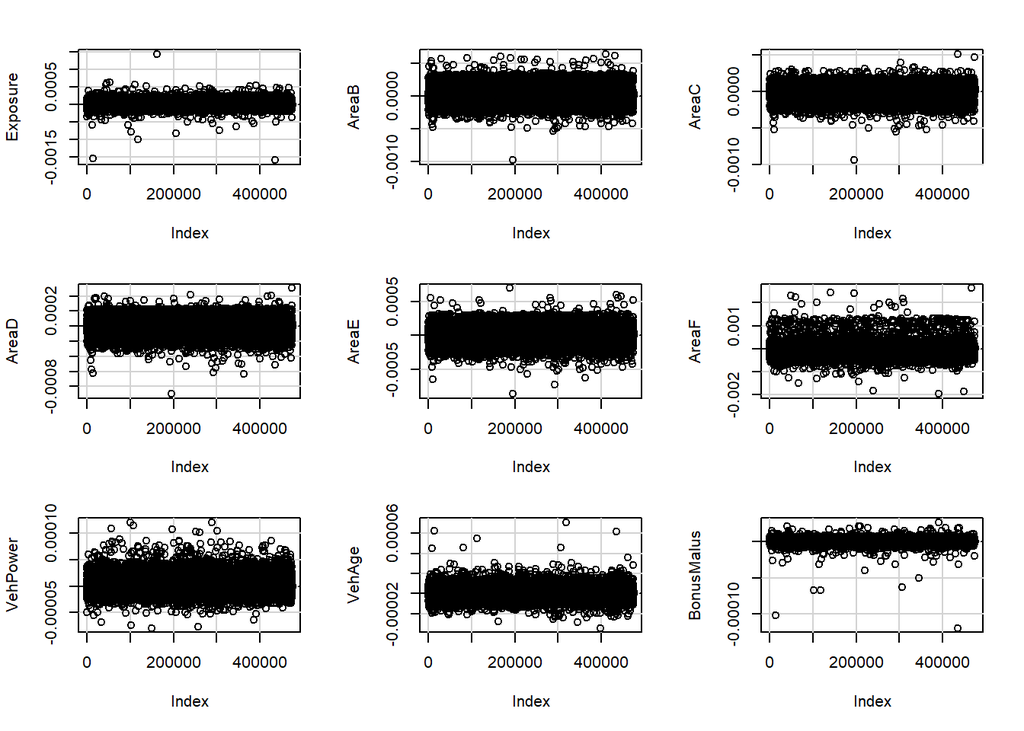

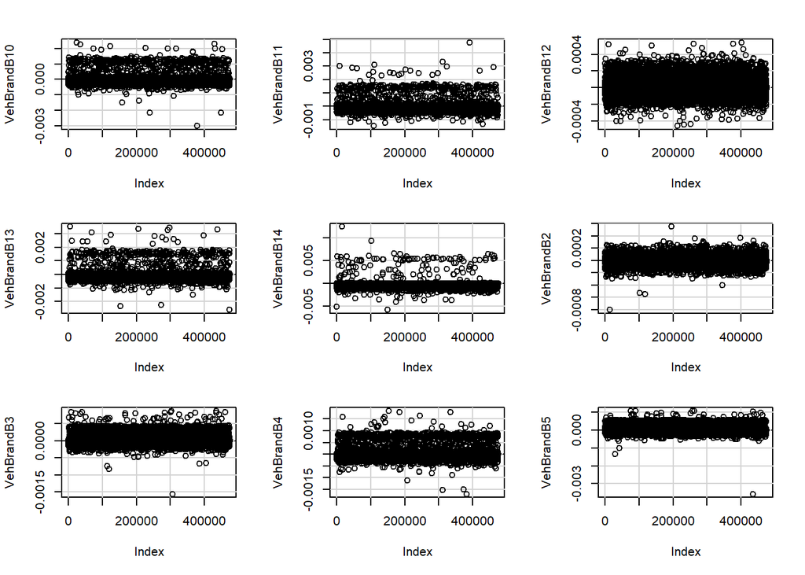

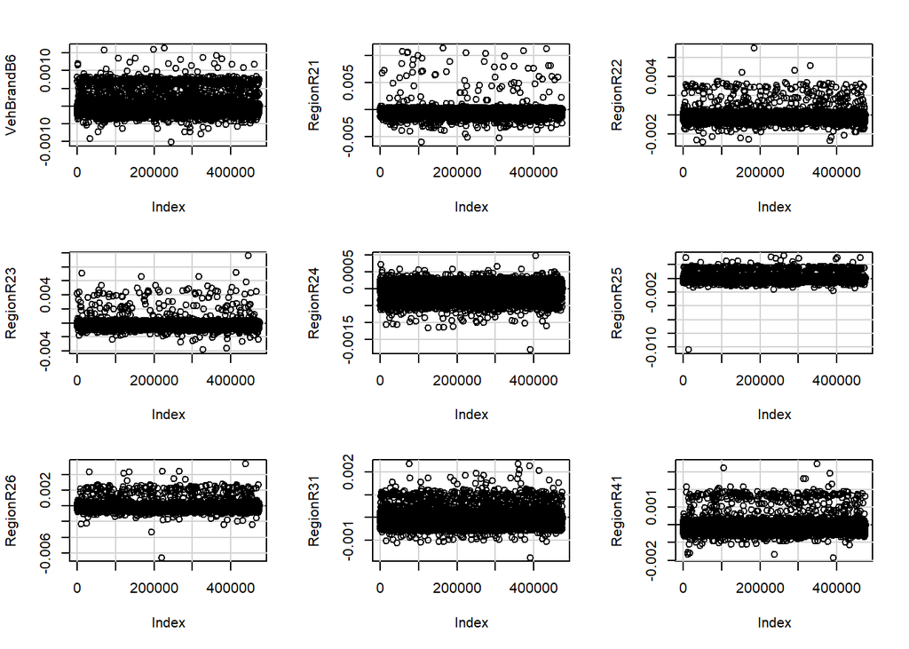

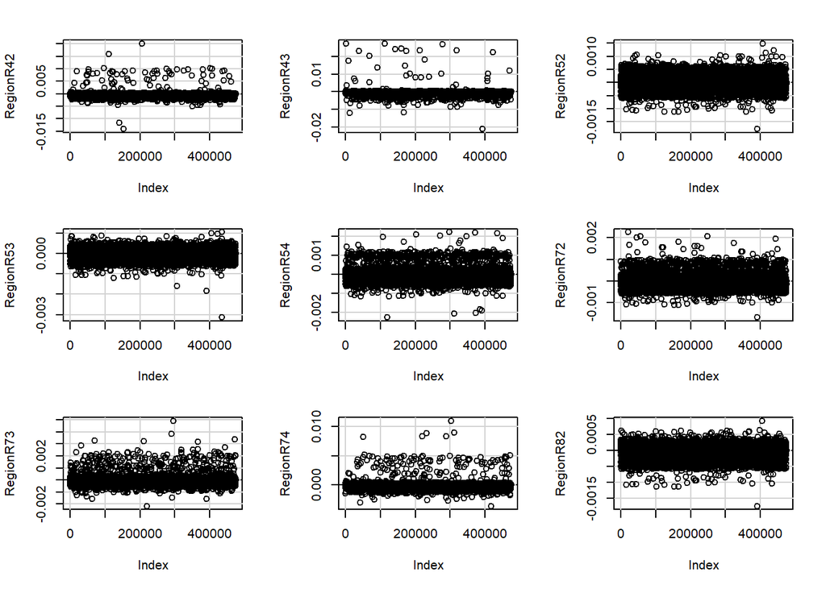

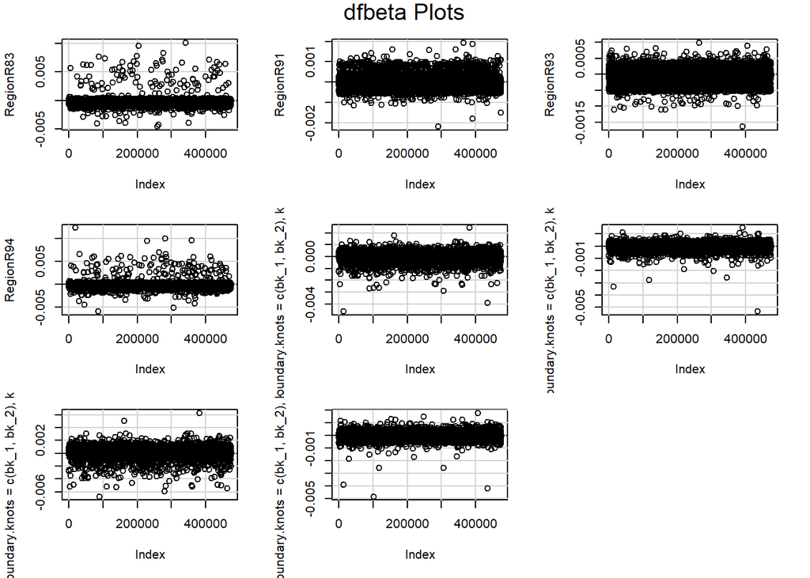

```r
dfbetaPlots(adaptive_lasso_retrained)
```